# README

## # Financial Econometrics Practical Exam

### Question 1: Fund Comparison and Performance Attribution

For this question, I analyzed the ABC_Fund’s risk and return profile relative to its benchmark and active manager peers. I began by cleaning and merging the data using dplyr and lubridate, ensuring the date fields were properly parsed.

```r
# Loading the datasets
Benchmark <- read_rds("data/Capped_SWIX.rds")
Active_Managers <- read_rds("data/Active_Managers.rds")
ABC_Fund <- read_rds("data/ABC_Fund.rds")  # Check for underscore error when typing
```

I then calculated the rolling 36-month beta of ABC_Fund against the benchmark using a sliding window regression. This rolling beta gave insight into how the fund’s market sensitivity evolved over time.

```r
# Date conversion
Benchmark <- Benchmark %>% mutate(date = ymd(date))
Active_Managers <- Active_Managers %>% mutate(date = ymd(date))
ABC_Fund <- ABC_Fund %>% mutate(date = ymd(date))

# Confirm if date conversion was successful
str(Benchmark)
```

```
## tibble [311 × 3] (S3: tbl_df/tbl/data.frame)
##  $ date   : Date[1:311], format: "1999-12-31" "2000-01-31" ...
##  $ Name   : chr [1:311] "FTSE/JSE Capped SWIX" "FTSE/JSE Capped SWIX" "FTSE/JSE Capped SWIX" "FTSE/JSE Capped SWIX" ...
##  $ Returns: num [1:311] 0.13111 -0.0129 -0.0617 0.00822 -0.06129 ...
```

```r
# Calculate a rolling 36-month (3-year) beta of ABC_Fund returns against Benchmark returns

# Step 1 : Joining ABC_Fund with Benchmark

# Merge ABC_Fund with Benchmark returns by date
ABC_vs_BM <- ABC_Fund %>%
  left_join(Benchmark, by = "date", suffix = c("_ABC", "_BM"))

# Quick check
head(ABC_vs_BM)
```

```
## # A tibble: 6 × 5
##   date       Returns_ABC Name_ABC Name_BM              Returns_BM
##   <date>           <dbl> <chr>    <chr>                     <dbl>
## 1 2012-07-31     0.0350  ABC_Fund FTSE/JSE Capped SWIX     0.0319
## 2 2012-08-31     0.0303  ABC_Fund FTSE/JSE Capped SWIX     0.0271
## 3 2012-09-30     0.00671 ABC_Fund FTSE/JSE Capped SWIX     0.0120
## 4 2012-10-31     0.0340  ABC_Fund FTSE/JSE Capped SWIX     0.0329
## 5 2012-11-30     0.0236  ABC_Fund FTSE/JSE Capped SWIX     0.0214
## 6 2012-12-31     0.0362  ABC_Fund FTSE/JSE Capped SWIX     0.0433
```

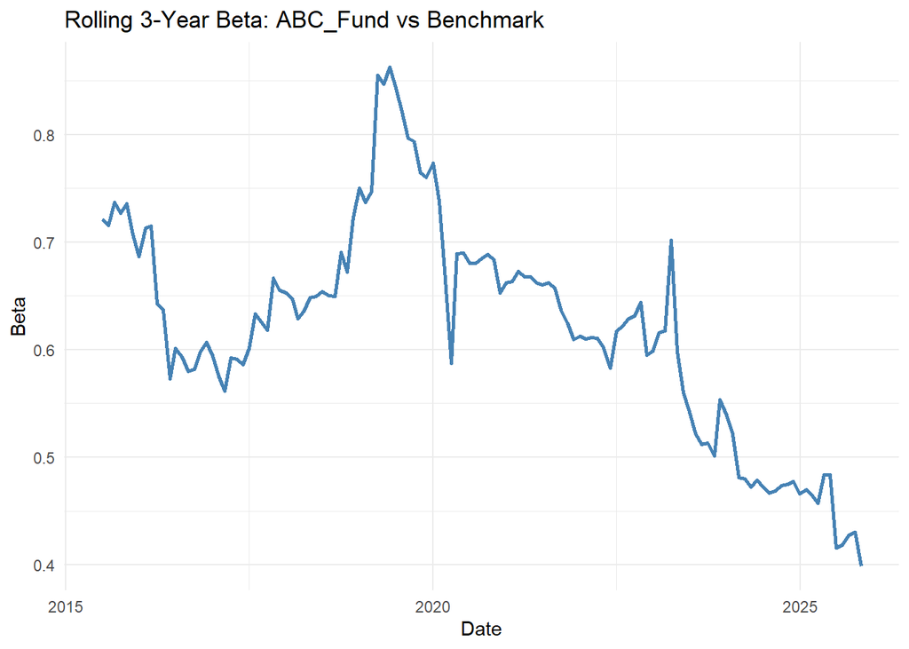

```r
# Step 2 : Rolling 36-month regression

# Set window size
window_size <- 36

# Creating a placeholder for results
rolling_beta <- data.frame(
  date = ABC_vs_BM$date[window_size:nrow(ABC_vs_BM)],
  beta = NA_real_
)

# Calculating beta in each window
for (i in window_size:nrow(ABC_vs_BM)) {
  window_data <- ABC_vs_BM[(i - window_size + 1):i, ]

# Simple linear regression: ABC on Benchmark
  model <- lm(Returns_ABC ~ Returns_BM, data = window_data)
  rolling_beta$beta[i - window_size + 1] <- coef(model)[2]
}
# Step 3 : Plot Rolling Beta

# Plot the rolling 3-year beta
ggplot(rolling_beta, aes(x = date, y = beta)) +
  geom_line(color = "steelblue", size = 1) +
  labs(title = "Rolling 3-Year Beta: ABC_Fund vs Benchmark",
       x = "Date", y = "Beta") +
  theme_minimal()
```

Additionally, in order to evaluate ABC Fund’s positioning against the broader industry, I applied this same rolling beta logic to each peer fund using a function. I visualized the distribution of betas as a boxplot overlaid with a highlighted point for ABC_Fund. This confirmed that the fund had a lower beta than most peers at the latest date, suggesting a relatively defensive stance.

```r
# How does my fund compare to my peers

# Step 1)  Create a function to compute rolling beta for any fund
# Rolling beta function
get_rolling_beta <- function(df, benchmark_df, window = 36) {

# Check if enough data for rolling regression
  if (nrow(df) < window) {
    return(NULL)
  }

# Merge with benchmark
  merged_df <- left_join(df, benchmark_df, by = "date", suffix = c("_fund", "_bm"))

# Set up empty result
  result <- data.frame(
    date = merged_df$date[window:nrow(merged_df)],
    beta = rep(NA, nrow(merged_df) - window + 1),
    Name = unique(df$Name)
  )

# Rolling regression
  for (i in window:nrow(merged_df)) {
    window_data <- merged_df[(i - window + 1):i, ]
    model <- lm(Returns_fund ~ Returns_bm, data = window_data)
    result$beta[i - window + 1] <- coef(model)[2]
  }

  return(result)
}

# Split dataset by manager
manager_list <- split(Active_Managers, Active_Managers$Name)

# Apply rolling beta function
rolling_betas_all <- lapply(manager_list, get_rolling_beta, benchmark_df = Benchmark)

# Drop Nulls
rolling_betas_all <- rolling_betas_all[!sapply(rolling_betas_all, is.null)]

# Combine into one dataframe
rolling_betas_df <- bind_rows(rolling_betas_all)

# Comparing the distribution of rolling betas across managers (How ABC compares to peers)
library(ggplot2)
library(dplyr)

# Filter for the most recent date in the data
latest_date <- max(rolling_betas_df$date, na.rm = TRUE)

# Filter rolling betas for the latest window
recent_betas <- rolling_betas_df %>%
  filter(date == latest_date)

# The function only worked on Active managers, not ABC_Fund
# Need to manually calculate the latest 3-year beta for ABC_Fund and then add it to the dataframe

unique(recent_betas$Name)
```

```
##   [1] "A105" "A131" "A183" "A209" "B106" "B132" "B184" "B210" "C133" "C159"
##  [11] "C211" "C55"  "D160" "D186" "D56"  "D82"  "E135" "E187" "E213" "E57"
##  [21] "F162" "F188" "F214" "F32"  "F58"  "F6"   "G111" "G163" "G215" "G33"
##  [31] "G59"  "G85"  "H138" "H190" "H216" "H60"  "I139" "I165" "I217" "I35"
##  [41] "I61"  "I87"  "I9"   "J114" "J166" "J192" "J218" "J36"  "J62"  "J88"
##  [51] "K11"  "K141" "K193" "K219" "K37"  "K63"  "K89"  "L116" "L194" "L220"
##  [61] "L38"  "L90"  "M117" "M13"  "M143" "M39"  "M65"  "M91"  "N14"  "N222"
##  [71] "N92"  "O145" "O171" "O197" "O223" "O93"  "P120" "P146" "P172" "P224"
##  [81] "P68"  "Q121" "Q147" "Q173" "Q199" "Q69"  "R148" "R174" "R200" "R96"
##  [91] "S123" "S175" "S97"  "T124" "T150" "T176" "T202" "T46"  "T98"  "U125"
## [101] "U177" "U203" "V100" "V126" "V152" "V204" "V48"  "W101" "W127" "W153"
## [111] "W179" "W205" "W23"  "W75"  "X102" "X128" "X180" "X206" "X24"  "Y103"
## [121] "Y129" "Y181" "Y25"  "Y51"  "Y77"  "Z104" "Z130" "Z156" "Z208" "Z26"
```

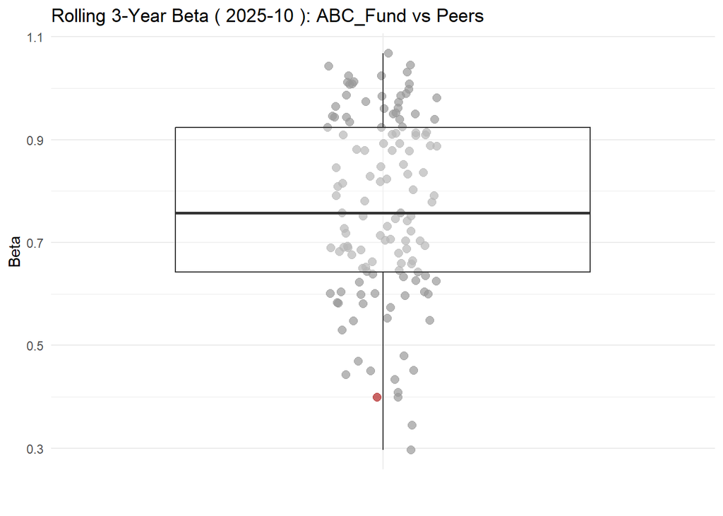

```r
# Step 1) Get the ABC_Fund's rolling beta data
ABC_beta <- get_rolling_beta(ABC_Fund, benchmark_df = Benchmark, window = 36)

# Step 2) Extract the most recent beta value
ABC_latest_beta <- tail(ABC_beta, 1)

# Step 3) Add it to the recent_betas dataframe
recent_betas_with_ABC <- bind_rows(
  recent_betas,
  data.frame(
    date = ABC_latest_beta$date,
    beta = ABC_latest_beta$beta,
    Name = "ABC_Fund"
  )
)

# Step 4) Create boxplot over scatter
ggplot(recent_betas_with_ABC, aes(x = "", y = beta)) +
  geom_jitter(
    aes(color = (Name == "ABC_Fund")),
    width = 0.1, size = 2.5, alpha = 0.7
  ) +
  geom_boxplot(alpha = 0.3, outlier.shape = NA) +
  scale_color_manual(values = c("grey60", "firebrick")) +
  labs(
    title = paste("Rolling 3-Year Beta (", format(latest_date, "%Y-%m"), "): ABC_Fund vs Peers"),
    y = "Beta", x = "", color = "Fund"
  ) +
  theme_minimal() +
  theme(legend.position = "none")
```

```r
# Confirm if beta is realistic (0.45)
ABC_tail <- tail(ABC_vs_BM, 36)
summary(lm(Returns_ABC ~ Returns_BM, data = ABC_tail))
```

```
##
## Call:
## lm(formula = Returns_ABC ~ Returns_BM, data = ABC_tail)
##
## Residuals:
##       Min        1Q    Median        3Q       Max
## -0.038571 -0.015419  0.001663  0.014210  0.032446
##
## Coefficients:
##             Estimate Std. Error t value Pr(>|t|)
## (Intercept) 0.005405   0.003276   1.650    0.108
## Returns_BM  0.399081   0.083613   4.773 3.38e-05 ***
## ---
## Signif. codes:  0 '***' 0.001 '**' 0.01 '*' 0.05 '.' 0.1 ' ' 1
##
## Residual standard error: 0.01792 on 34 degrees of freedom
## Multiple R-squared:  0.4012, Adjusted R-squared:  0.3836
## F-statistic: 22.78 on 1 and 34 DF,  p-value: 3.377e-05
```

Next, I assessed how much of ABC_Fund’s returns were driven by benchmark exposure by comparing rolling R² values across funds. This helped determine whether the fund’s returns were explained largely by the benchmark or if they reflected more idiosyncratic strategies.

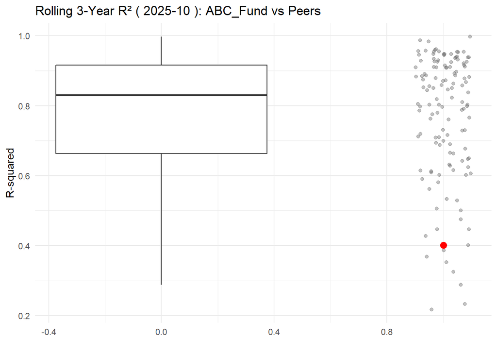

```r
# How much does fund differ from rest of industry in terms of what drives returns
# Compare R-sqaured values from regressions : Is fund more or less aligned with the benchmark than my peers are

# Step 1) Create  function to calculate rolling R^2
get_rolling_r2 <- function(df, benchmark_df, window = 36) {
  if (nrow(df) < window) {
    return(NULL)
  }

  merged_df <- left_join(df, benchmark_df, by = "date", suffix = c("_fund", "_bm"))

  result <- data.frame(
    date = merged_df$date[window:nrow(merged_df)],
    r_squared = rep(NA_real_, nrow(merged_df) - window + 1),
    Name = unique(df$Name)
  )

  for (i in window:nrow(merged_df)) {
    window_data <- merged_df[(i - window + 1):i, ]
    model <- lm(Returns_fund ~ Returns_bm, data = window_data)
    result$r_squared[i - window + 1] <- summary(model)$r.squared
  }

  return(result)
}

# step 2)  Apply function to all peer funds

# Split peer data into list by manager
manager_list_r2 <- split(Active_Managers, Active_Managers$Name)

# Apply rolling R^2 function to each manager
rolling_r2_all <- lapply(manager_list_r2, get_rolling_r2, benchmark_df = Benchmark)

# Drop Nulls
rolling_r2_all <- rolling_r2_all[!sapply(rolling_r2_all, is.null)]

# Combine into one dataframe
rolling_r2_df <- bind_rows(rolling_r2_all)

# Step 3)  Extract the latest R^2 for each manager

# Get most recent date
latest_date_r2 <- max(rolling_r2_df$date)

# Filter to latest R^2s
recent_r2 <- rolling_r2_df %>%
  filter(date == latest_date_r2)

# step 4)  Get ABC_Funds latest R^2

# Merge ABC_Fund with Benchmark
ABC_vs_BM_r2 <- ABC_Fund %>%
  left_join(Benchmark, by = "date", suffix = c("_ABC", "_BM"))

# Take latest 36 months
ABC_tail_r2 <- tail(ABC_vs_BM_r2, 36)

# Run regression
model_ABC <- lm(Returns_ABC ~ Returns_BM, data = ABC_tail_r2)
ABC_r2_latest <- summary(model_ABC)$r.squared


# step 5) Plot : ABC_Fund vs Peer R^2s
ggplot(recent_r2, aes(y = r_squared)) +
  geom_boxplot(outlier.shape = NA) +
  geom_jitter(aes(x = 1, y = r_squared), width = 0.1, alpha = 0.4, color = "grey40") +
  annotate("point", x = 1, y = ABC_r2_latest, color = "red", size = 3) +
  labs(
    title = paste("Rolling 3-Year R² (", format(latest_date_r2, "%Y-%m"), "): ABC_Fund vs Peers"),
    y = "R-squared",
    x = ""
  ) +
  theme_minimal()
```

ABC_Fund had one of the lower R² values in the peer group, indicating that its performance was less benchmark-driven, likely reflecting more active management.

I then turned to cumulative return performance over the full sample. I computed cumulative returns for ABC_Fund and all peers, and visualized this with a grey background of peers and ABC_Fund in red. To better illustrate peer dispersion, I also created a ribbon plot showing the interquartile range (IQR) of peer performance.

```r
# Provide a nice visual illustration of my funds relative performance to peers over time

# Step 1)  Calculate cumulative returns

# Function to compute cumulative returns
# This function takes a group's data and its associated name (from .y), calculates cumulative returns
compute_cum_returns <- function(df, group_info) {
  df %>%
    arrange(date) %>%
    mutate(cum_return = cumprod(1 + Returns)) %>%
    select(date, cum_return)  # DON'T include Name
}

# Apply to all active managers
peer_returns <- Active_Managers %>%
  group_by(Name) %>%
  group_modify(compute_cum_returns) %>%  # 'Name' added automatically
  ungroup()

# Check column names
glimpse(ABC_Fund)
```

```
## Rows: 160
## Columns: 3
## $ date    <date> 2012-07-31, 2012-08-31, 2012-09-30, 2012-10-31, 2012-11-30, 2…
## $ Returns <dbl> 0.0349878, 0.0303066, 0.0067147, 0.0340319, 0.0235661, 0.03623…
## $ Name    <chr> "ABC_Fund", "ABC_Fund", "ABC_Fund", "ABC_Fund", "ABC_Fund", "A…
```

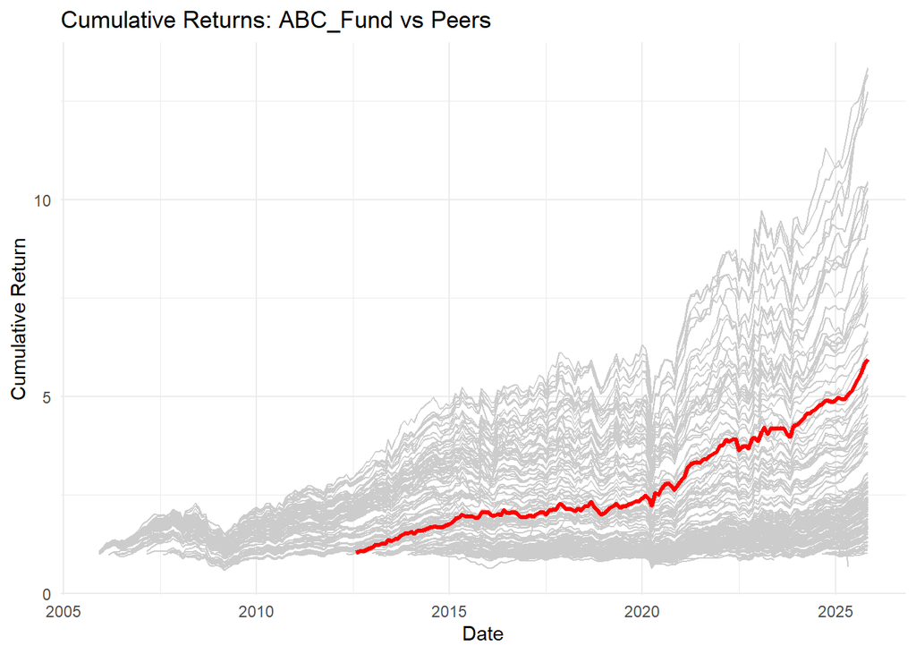

```r
# ABC_Fund cumulative returns
ABC_cum <- ABC_Fund %>%
  arrange(date) %>%
  mutate(cum_return = cumprod(1 + Returns)) %>%
  select(date, cum_return, Name)


# Step 2) Combine and plot cumulative returns over time
all_cum_returns <- bind_rows(peer_returns, ABC_cum)

ggplot(peer_returns, aes(x = date, y = cum_return, group = Name)) +
  geom_line(color = "grey80") +
  geom_line(data = ABC_cum, aes(x = date, y = cum_return), color = "red", size = 1.2) +
  labs(
    title = "Cumulative Returns: ABC_Fund vs Peers",
    x = "Date", y = "Cumulative Return"
  ) +
  theme_minimal()
```

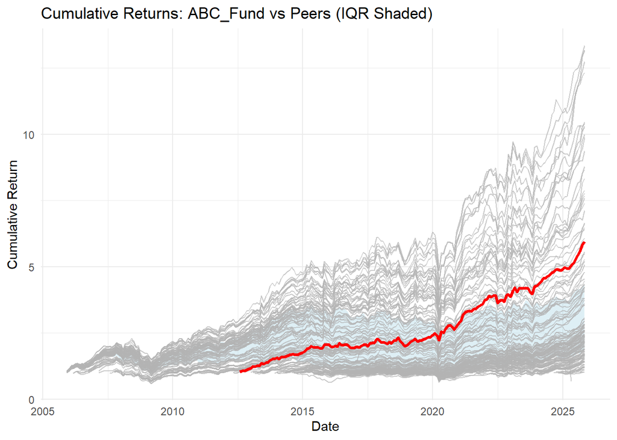

```r
# Step 3) Preparing Peer IQR for Ribbon Plot

# Compute the interquartile range (25th and 75th percentile) of cumulative returns at each date
peer_iqr <- peer_returns %>%
  group_by(date) %>%
  summarise(
    iqr_lower = quantile(cum_return, 0.25, na.rm = TRUE),
    iqr_upper = quantile(cum_return, 0.75, na.rm = TRUE)
  )

# Plot Cumulative Returns with IQR Band and ABC_Fund Highlighted

ggplot() +
  # Add IQR ribbon for peer dispersion (shaded area)
  geom_ribbon(data = peer_iqr, aes(x = date, ymin = iqr_lower, ymax = iqr_upper),
              fill = "lightblue", alpha = 0.4) +

  # Plot all peers in grey
  geom_line(data = peer_returns, aes(x = date, y = cum_return, group = Name),
            color = "grey70", size = 0.5, alpha = 0.7) +

  # Highlight ABC_Fund in red
  geom_line(data = ABC_cum, aes(x = date, y = cum_return),
            color = "red", size = 1.2) +

  # Axis labels and title
  labs(
    title = "Cumulative Returns: ABC_Fund vs Peers (IQR Shaded)",
    x = "Date",
    y = "Cumulative Return"
  ) +
  theme_minimal()
```

### Question 2 : Peaks and Trough

In this question, I explored whether smaller stocks are more volatile than larger ones, and examined how peak-to-trough drawdowns vary across different size groups and sectors on the JSE over the past decade. The goal was to assess the relative riskiness of local equities through both volatility and downside performance.

I began by loading and cleaning the holdings and returns data. Missing values were filtered out, and I ensured that key variables like Group and Weight were not missing.

```r
# Load libraries
library(tidyverse)
library(lubridate)

getwd()
```

```
## [1] "C:/Users/tapiw/OneDrive/Documents/Desktop/Fin metrics exam final"
```

```r
# Load data for Question 2
holdrets <- read_rds("Data/Hold_Rets_Sectors.rds")
port_holds <- read_rds("Data/Fund_Holds.rds")

# Quick peek at structure
glimpse(holdrets)
```

```
## Rows: 384,054
## Columns: 6
## $ date    <date> 2015-01-02, 2015-01-02, 2015-01-02, 2015-01-02, 2015-01-02, 2…
## $ Tickers <chr> "SAB", "NPN", "CFR", "MTN", "AGL", "SOL", "BTI", "SBK", "OML",…
## $ Return  <dbl> -1.037350e-02, 9.306202e-03, -2.857143e-03, -1.991799e-02, -7.…
## $ Weight  <dbl> 0.041875564, 0.106271643, 0.025070645, 0.080830696, 0.02894426…
## $ Group   <chr> "Large_Caps", "Large_Caps", "Large_Caps", "Large_Caps", "Large…
## $ Sector  <chr> "Industrials", "Industrials", "Industrials", "Industrials", "R…
```

```r
# Check NA across all columns
holdrets %>%
  summarise(across(everything(), ~ sum(is.na(.))))
```

```
## # A tibble: 1 × 6
##    date Tickers Return Weight Group Sector
##   <int>   <int>  <int>  <int> <int>  <int>
## 1     0       0     10      0  1383      0
```

```r
# Filter out rows with missing values
holdrets <- holdrets %>%
  filter(complete.cases(.))

# Remove rows missing Group or Weight (Group is critical for size analysis)
holdrets <- holdrets %>%
  filter(!is.na(Group), !is.na(Weight))
```

Are Smaller Stocks More Volatile?

To test whether small caps are more volatile, I calculated standard deviation of returns per stock, grouped by size (Group), and visualised the distribution using a boxplot.

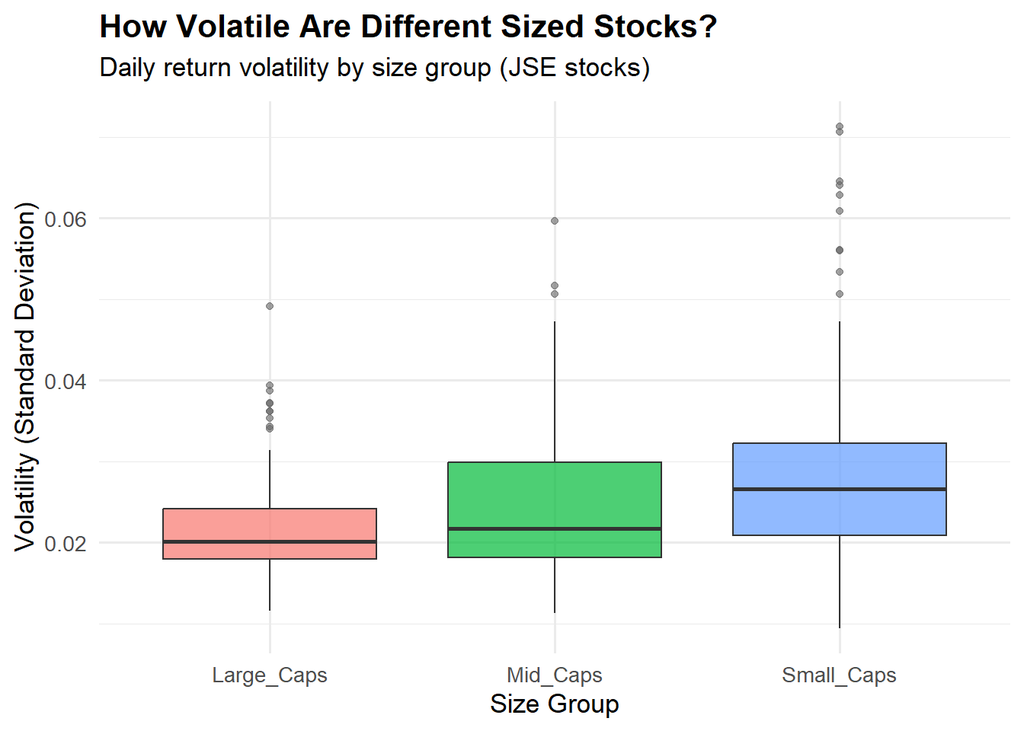

```r
# Are smaller stocks more volatile than larger stocks locally ?
# Want to check for relationship between stock size (group) and return volatility

# Step 1) Calculate return volatility per stock
vol_by_ticker <- holdrets %>%
  group_by(Tickers, Group) %>%
  summarise(volatility = sd(Return, na.rm = TRUE), .groups = "drop")

view(vol_by_ticker)

# Step 2) Visualise volatility by size group
ggplot(vol_by_ticker, aes(x = Group, y = volatility, fill = Group)) +
  geom_boxplot(alpha = 0.7, outlier.colour = "gray40", outlier.alpha = 0.6) +
  labs(
    title = "How Volatile Are Different Sized Stocks?",
    subtitle = "Daily return volatility by size group (JSE stocks)",
    x = "Size Group",
    y = "Volatility (Standard Deviation)"
  ) +
  theme_minimal(base_size = 13) +
  theme(
    legend.position = "none",
    plot.title = element_text(face = "bold"),
    plot.subtitle = element_text(margin = margin(b = 10))
  )
```

Peak-to-Trough Drawdowns : By Size Group

Next, I assessed worst annual drawdowns across stock size groups using a rolling cumulative return approach. I grouped by year, sector, and size to track the worst drop from peak for each stock.

```r
# Compare the typical peak-to-trough movement of different size groups and sectors for locally listed stocks for different years over the past decade.

# Step 1) : Compute Rolling Peak-to-Trough Declines for each stock
# Load packages
library(dplyr)
library(tidyr)
library(zoo)
```

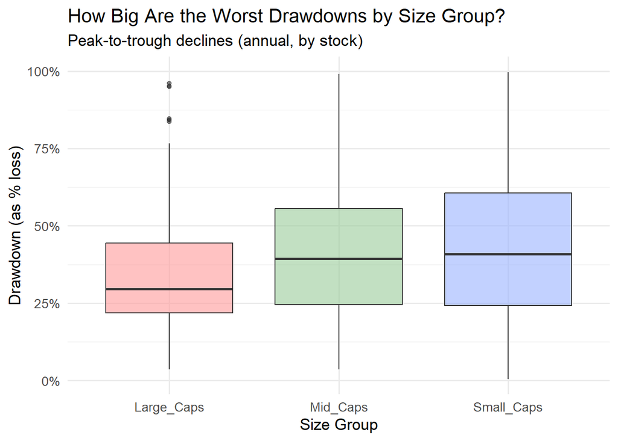

```r
# Arrange by Ticker and Date
holdrets <- holdrets %>%
  arrange(Tickers, date)

# Group by stock
drawdowns <- holdrets %>%
  group_by(Tickers) %>%
  mutate(
    cum_return = cumprod(1 + Return),
    cum_max = cummax(cum_return),
    drawdown = cum_return / cum_max - 1
  ) %>%
  ungroup()

# Step 2) Extract the Maximum Drawdown by year, sector and size
library(lubridate)

drawdown_summary <- drawdowns %>%
  mutate(year = year(date)) %>%
  group_by(year, Sector, Group, Tickers) %>%
  summarise(max_dd = min(drawdown, na.rm = TRUE), .groups = "drop")

# Step 3) Visualize peak-to-trough across Groups(using Boxplot)
# Will show the distrubution of worst drawdowns by size group

library(ggplot2)

ggplot(drawdown_summary, aes(x = Group, y = abs(max_dd), fill = Group)) +
  geom_boxplot(alpha = 0.6) +
  labs(
    title = "How Big Are the Worst Drawdowns by Size Group?",
    subtitle = "Peak-to-trough declines (annual, by stock)",
    x = "Size Group", y = "Drawdown (as % loss)"
  ) +
  scale_y_continuous(labels = scales::percent) +
  scale_fill_manual(values = c("Large_Caps" = "#FF9999", "Mid_Caps" = "#99CC99", "Small_Caps" = "#99B2FF")) +
  theme_minimal(base_size = 13) +
  theme(legend.position = "none")
```

Peak-to-Trough Drawdowns : By Sector

I then repeated the analysis at the sector level, identifying which industries typically experience the worst annual losses.

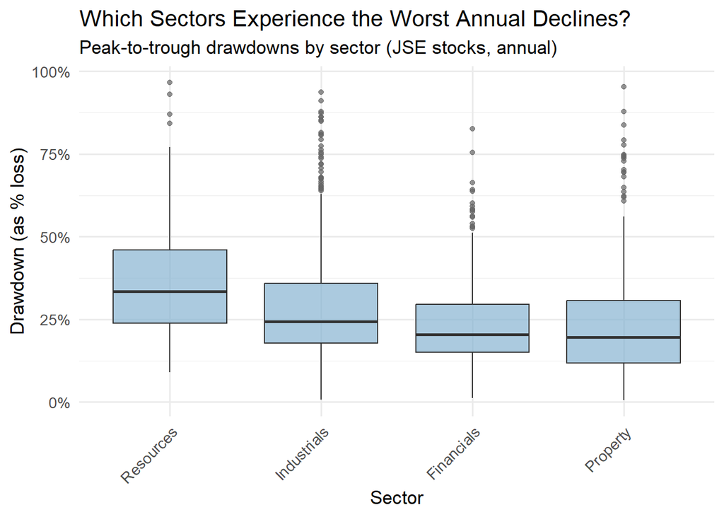

```r
# Let explore the same idea across sectors
# Will help us understand which sectors typically face the worst annual losses

# Step 1) Adding "Year" column so we can calculate per-year drawdowns
holdrets <- holdrets %>%
  mutate(Year = year(date))

# Step 2) For each stock in each year, calculate the cumulative return path
# Then find the peak value along that path and compute how far it falls from that peak (drawdown = % loss from the peak)
sector_drawdowns <- holdrets %>%
  arrange(Tickers, date) %>%
  group_by(Tickers, Sector, Year) %>%
  mutate(
    cumulative_return = cumprod(1 + Return),        # Product of 1 + daily return (running)
    peak = cummax(cumulative_return),               # highest value reached up to that point
    drawdown = cumulative_return / peak - 1         # % drop from peak at each point (drawdown)
  ) %>%
  summarise(
    worst_drawdown = min(drawdown, na.rm = TRUE),   # pick worst drawdown in the year for that stock
    .groups = "drop"
  )

# Step 3) Now visualise this : Using boxplot of worst annual drawdowns by Sector
# Each point is a stock in a year, grouped by sector
ggplot(sector_drawdowns,
       aes(x = fct_reorder(Sector, worst_drawdown, .fun = median),
           y = abs(worst_drawdown))) +
  geom_boxplot(fill = "#86b3d1", alpha = 0.7, outlier.color = "grey40") +
  scale_y_continuous(labels = scales::percent_format(accuracy = 1)) +
  labs(
    title = "Which Sectors Experience the Worst Annual Declines?",
    subtitle = "Peak-to-trough drawdowns by sector (JSE stocks, annual)",
    x = "Sector",
    y = "Drawdown (as % loss)"
  ) +
  theme_minimal(base_size = 13) +
  theme(axis.text.x = element_text(angle = 45, hjust = 1))
```

Bonus Insight :Do Smaller Stocks Within Sectors Fall More?

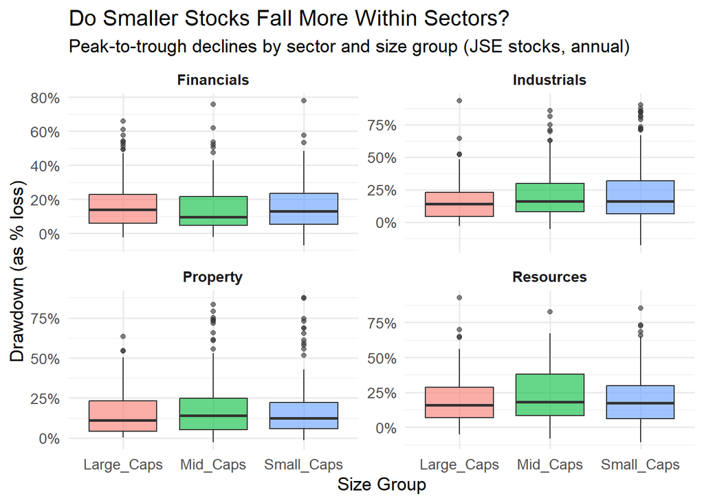

```r
# Other interesting insights
# Do sector-level drawdowns vary by size group ?
# (Do small caps in sector X draw down more than large caps in the same sector?)

# Step 1) Group by year, ticker and calculate drawdown per stock per year
drawdown_sector_size <- holdrets %>%
  mutate(year = year(date)) %>%
  group_by(Tickers, year, Sector, Group) %>%
  summarise(drawdown = min(cumprod(1 + Return)) - 1, .groups = "drop")

# Step 2) Plot a faceted Boxplot by sector, comparing size groups
ggplot(drawdown_sector_size, aes(x = Group, y = -drawdown, fill = Group)) +
  geom_boxplot(alpha = 0.6) +
  facet_wrap(~ Sector, scales = "free_y") +
  scale_y_continuous(labels = scales::percent) +
  labs(
    title = "Do Smaller Stocks Fall More Within Sectors?",
    subtitle = "Peak-to-trough declines by sector and size group (JSE stocks, annual)",
    x = "Size Group",
    y = "Drawdown (as % loss)"
  ) +
  theme_minimal(base_size = 13) +
  theme(
    legend.position = "none",
    strip.text = element_text(face = "bold")
  )
```

### Question 3 : Momentum

This question explores momentum as an investment signal on the JSE over the past decade. I evaluate the strength, consistency, and profitability of momentum using:

- Information Coefficient (IC)
- Signal Decay
- Quintile Performance
- Fund Analysis

Loading data and required packages

```r
# Load required libraries
library(tidyverse)
library(lubridate)
 install.packages("here")
# Load return and fund holdings data (relative to project root)
holdrets <- read_rds("Data/Hold_Rets_Sectors.rds")
port_holds <- read_rds("Data/Fund_Holds.rds")
```

Momentum Signal Definition

```r
# Define Momentum :
# Start by creating a 12-month trailing momentum signal for each stock

# Will define momentum as Cumulative return over past 12 months, skipping the most recent month (textbook approach)

# Create Momentum signal (12 month lagged returns, skipping 1 month)
library(slider)
# Calculate momentum per stock
momentum_data <- holdrets %>%
    group_by(Tickers) %>%
    arrange(date) %>%
    mutate(
        # Skip the most recent month and sum the prior 11
        momentum = slide_dbl(Return, ~ prod(1 + .x, na.rm = TRUE) - 1,
                             .before = 12, .after = -2, .complete = TRUE)
    ) %>%
    ungroup()

glimpse(momentum_data)
```

```
## Rows: 384,054
## Columns: 7
## $ date     <date> 2015-01-02, 2015-01-02, 2015-01-02, 2015-01-02, 2015-01-02, …
## $ Tickers  <chr> "SAB", "NPN", "CFR", "MTN", "AGL", "SOL", "BTI", "SBK", "OML"…
## $ Return   <dbl> -1.037350e-02, 9.306202e-03, -2.857143e-03, -1.991799e-02, -7…
## $ Weight   <dbl> 0.041875564, 0.106271643, 0.025070645, 0.080830696, 0.0289442…
## $ Group    <chr> "Large_Caps", "Large_Caps", "Large_Caps", "Large_Caps", "Larg…
## $ Sector   <chr> "Industrials", "Industrials", "Industrials", "Industrials", "…
## $ momentum <dbl> NA, NA, NA, NA, NA, NA, NA, NA, NA, NA, NA, NA, NA, NA, NA, N…
```

Information Coefficient (IC)

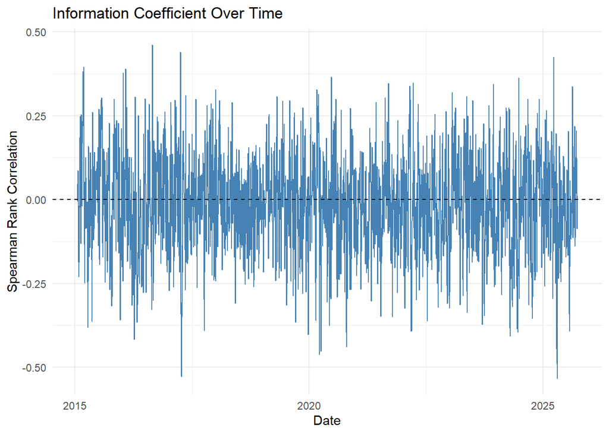

```r
# Information Coefficent
# Measure how well the momentum signal predicts future 3-month returns using Rank Correlation.

# Add 3-month Forward Return by ticker
momentum_data <- momentum_data %>%
    group_by(Tickers) %>%
    arrange(date) %>%
    mutate(
        forward_3m_ret = lead(Return, 1) + lead(Return, 2) + lead(Return, 3)
    ) %>%
    ungroup()

# Compute IC (Rank correlation)
# Keep only rows with valid momentum and forward returns
ic_data <- momentum_data %>%
    filter(!is.na(momentum), !is.na(forward_3m_ret)) %>%
    group_by(date) %>%
    summarise(
        ic = cor(rank(momentum), rank(forward_3m_ret), method = "spearman")
    )

# Visualise IC over time
ic_data %>%
    ggplot(aes(x = date, y = ic)) +
    geom_line(color = "steelblue") +
    geom_hline(yintercept = 0, linetype = "dashed") +
    labs(
        title = "Information Coefficient Over Time",
        y = "Spearman Rank Correlation",
        x = "Date"
    ) +
    theme_minimal()
```

Signal Decay

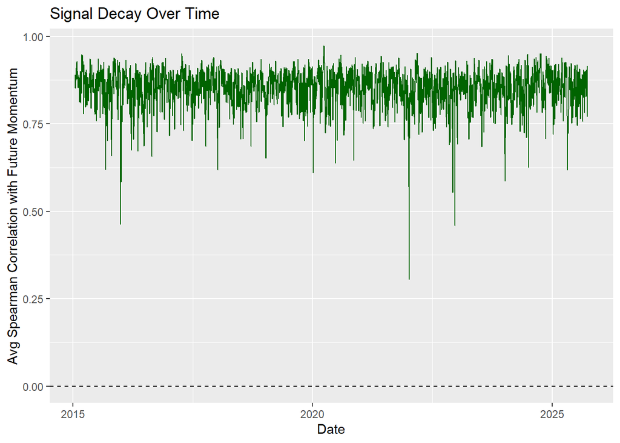

```r
# Signal Decay
# This is the correlation between the current momentum signal and future signal rankings, typically over the next 3 months.
# Shows signal persistance

# Step 1) Create lagged momentum signals
momentum_decay_data <- momentum_data %>%
    group_by(Tickers) %>%
    arrange(date) %>%
    mutate(
        mom_lead_1 = lead(momentum, 1),
        mom_lead_2 = lead(momentum, 2),
        mom_lead_3 = lead(momentum, 3)
    ) %>%
    ungroup()

# Step 2) Compute signal decay over time
decay_by_month <- momentum_decay_data %>%
    group_by(date) %>%
    filter(!is.na(momentum) & !is.na(mom_lead_1) & !is.na(mom_lead_2) & !is.na(mom_lead_3)) %>%
    summarise(
        decay = mean(cor(momentum, mom_lead_1, method = "spearman"),
                     cor(momentum, mom_lead_2, method = "spearman"),
                     cor(momentum, mom_lead_3, method = "spearman")),
        .groups = 'drop'
    )

# Step 3) Plot the decay
ggplot(decay_by_month, aes(x = date, y = decay)) +
    geom_line(color = "darkgreen") +
    geom_hline(yintercept = 0, linetype = "dashed") +
    labs(title = "Signal Decay Over Time",
         x = "Date",
         y = "Avg Spearman Correlation with Future Momentum")
```

Quintile Performance

After that I plotted the cumulative long–short return and extracted, mean spread, median spread, and hit rate (probability of positive spread).

```r
# Quintile Performance (Long vs Short)
# For every date, assign each stock to a quintile based on its momentum signal.
# Quintile 1 : Highest momentum (top 20%)
# Quintile 2 : Lowedt momentum (bottom 20%)

# Step 1) Assign quantiles based on momentum
quintile_data <- momentum_data %>%
    filter(!is.na(momentum), !is.na(forward_3m_ret)) %>%
    group_by(date) %>%
    mutate(
        quintile = ntile(momentum, 5)
    ) %>%
    ungroup()

# Step 2) Compute avergae forward return per quintile
quintile_perf <- quintile_data %>%
    group_by(date, quintile) %>%
    summarise(
        avg_fwd3m = mean(forward_3m_ret, na.rm = TRUE),
        .groups = 'drop'
    )

# Step 3) Derive long-short (Top minus Bottom)
ls_perf <- quintile_perf %>%
    pivot_wider(names_from = quintile, values_from = avg_fwd3m, names_prefix = "Q") %>%
    mutate(
        long_short = Q1 - Q5
    ) %>%
    select(date, long_short)

# Summary stats over full sample
ls_summary <- ls_perf %>%
    summarise(
        mean_ls = mean(long_short, na.rm = TRUE),
        median_ls = median(long_short, na.rm = TRUE),
        hit_rate = mean(long_short > 0, na.rm = TRUE)
    )

ls_summary
```

```
## # A tibble: 1 × 3
##    mean_ls median_ls hit_rate
##      <dbl>     <dbl>    <dbl>
## 1 0.000842  0.000806    0.527
```

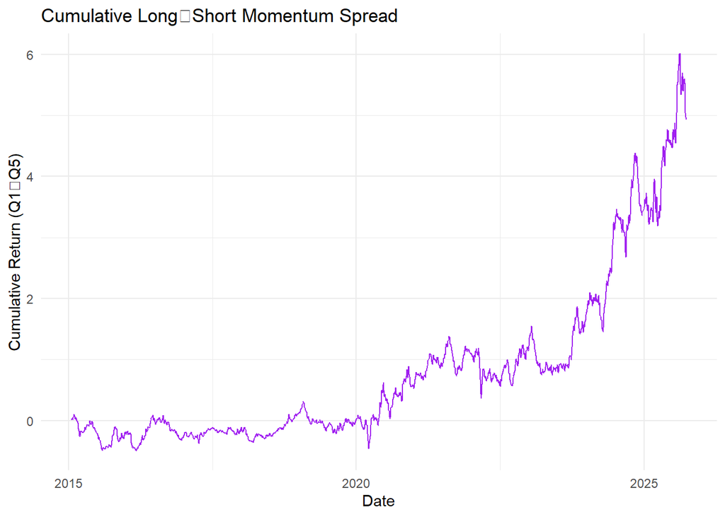

```r
# Step 4) Visualize cumulative long-short performance
ls_perf %>%
    mutate(cum_ls = cumprod(1 + long_short) - 1) %>%
    ggplot(aes(x = date, y = cum_ls)) +
    geom_line(color = "purple") +
    labs(
        title = "Cumulative Long‑Short Momentum Spread",
        x = "Date",
        y = "Cumulative Return (Q1‑Q5)"
    ) +
    theme_minimal()
```

Fund vs Momentum Signal

Finally, I compared a local fund’s stock holdings to the momentum signal, checking if the fund tilts toward high-momentum stocks.

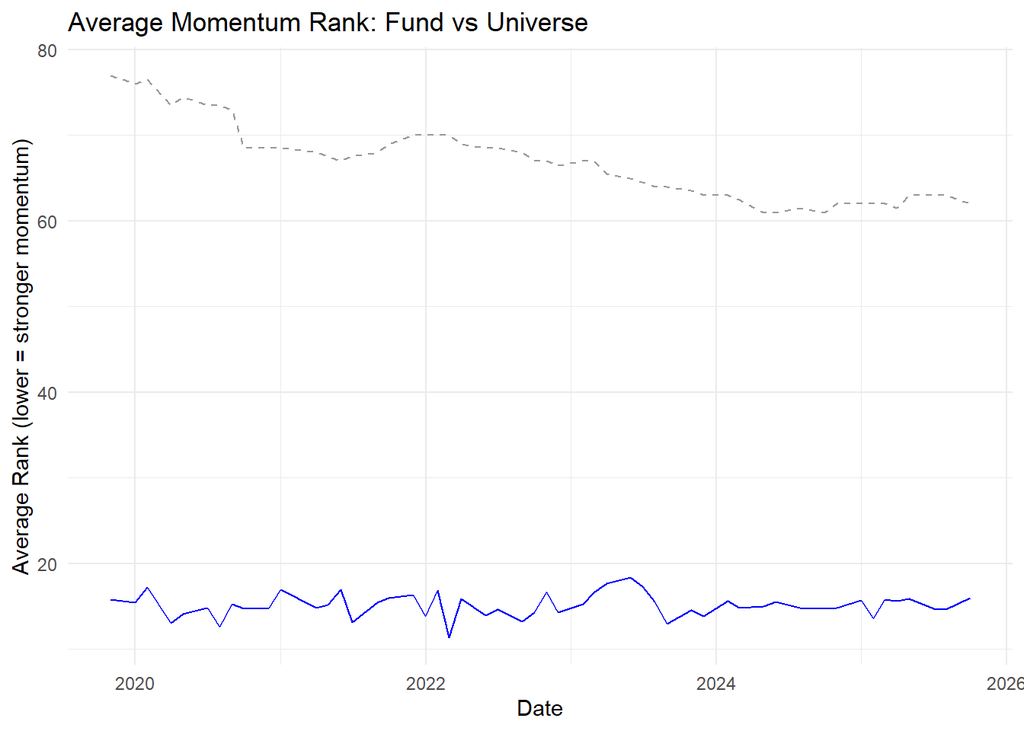

```r
# Compare the Fund to the momemntum signal
# Want to check whether colleagues fund appears to be capturing momentum signal and its performance relative to signal

# Prepare Fund data to avoid name conflicts
fund_clean <- port_holds %>%
    select(date, Tickers, fund_weight = Weight)

# Step 1) Join Fund Holdings with momentum data
fund_mom <- fund_clean %>%
    inner_join(momentum_data, by = c("date", "Tickers")) %>%
    filter(!is.na(momentum)) %>%
    select(date, Tickers, fund_weight, momentum)

# Step 2) Compute average momentum ranking for fund holdings
fund_rank_summary <- fund_mom %>%
    group_by(date) %>%
    mutate(rank_mom = rank(-momentum)) %>%
    summarise(
        avg_fund_rank = weighted.mean(rank_mom, fund_weight, na.rm = TRUE),
        .groups = "drop"
    )

# Step 3) Compute universe average rank for each date (unweighted)
univ_rank_summary <- momentum_data %>%
    filter(!is.na(momentum)) %>%
    group_by(date) %>%
    mutate(rank_mom = rank(-momentum)) %>%
    summarise(
        avg_univ_rank = mean(rank_mom, na.rm = TRUE),
        .groups = "drop"
    )

# Step 4) Combine the 2 summaries
fund_vs_univ <- fund_rank_summary %>%
    inner_join(univ_rank_summary, by = "date")

# Step 5) Plot the comparison
fund_vs_univ %>%
    ggplot(aes(x = date)) +
    geom_line(aes(y = avg_fund_rank), color = "blue") +
    geom_line(aes(y = avg_univ_rank), color = "grey60", linetype = "dashed") +
    labs(
        title = "Average Momentum Rank: Fund vs Universe",
        x = "Date",
        y = "Average Rank (lower = stronger momentum)"
    ) +
    theme_minimal()
```

This was visualised as a time series plot comparing the fund’s average rank to the market’s average. Lower ranks indicate higher momentum exposure.

### Question 4 : Volatility and GARCH Estimates

In this section, I analyse the volatility and valuation profile of the South African Rand (ZAR) relative to other major currencies. My objective was to evaluate :

- Whether the ZAR has been one of the most volatile currencies in recent years.
- Whether the ZAR performs better during G10 carry-friendly environments and when it is relatively undervalued.

Due to technical constraints, I focus on realised volatility, implied volatility, and valuation-based performance regimes.

Loading data and packages

```r
# Load required libraries
library(tidyverse)
library(lubridate)
library(here)

# Set working directory to project root for reproducibility
setwd(here::here())

# Load currency datasets
cncy       <- read_rds("Data/currencies.rds")
cncy_carry <- read_rds("Data/cncy_Carry.rds")
cncy_value <- read_rds("Data/cncy_value.rds")
cncy_iv    <- read_rds("Data/cncyIV.rds")
bbdxy      <- read_rds("Data/bbdxy.rds")
```

Realised Volatility

```r
# Realized volatility
# Measure 30-day rolling annualised volaitility of ZAR comparing with other major currencies

# Load required packages
library(slider)
library(scales)
```

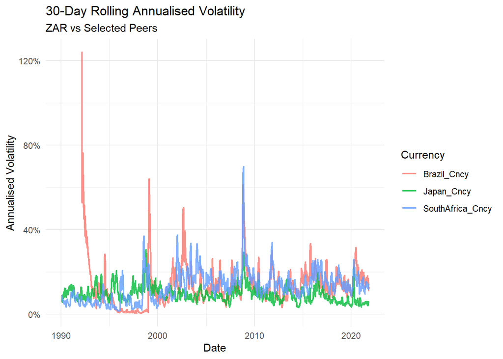

```r
# Step 1) Define currencies to analyse
major_currencies <- c("SouthAfrica_Cncy", "US_Cncy", "Euro_Cncy",
                      "UK_Cncy", "Japan_Cncy", "Australia_Cncy",
                      "Brazil_Cncy")

# Step 2) Filter and Compute log returns
vol_data <- cncy %>%
    filter(Name %in% major_currencies) %>%
    arrange(Name, date) %>%
    group_by(Name) %>%
    mutate(
        ret = log(Price / lag(Price))
    ) %>%
    filter(!is.na(ret)) %>%
    # Rolling 30-day annualised vol: std dev × sqrt(252)
    mutate(
        vol_30d = slide_dbl(ret, sd, .before = 29, .complete = TRUE) * sqrt(252)
    ) %>%
    ungroup()

# Step 3) Quick Plot of ZAR vs others
vol_data %>%
    filter(Name %in% c("SouthAfrica_Cncy", "Brazil_Cncy", "Australia_Cncy", "Japan_Cncy")) %>%
    ggplot(aes(x = date, y = vol_30d, color = Name)) +
    geom_line(size = 0.8, alpha = 0.8) +
    scale_y_continuous(labels = percent_format(accuracy = 1)) +
    labs(
        title = "30-Day Rolling Annualised Volatility",
        subtitle = "ZAR vs Selected Peers",
        x = "Date", y = "Annualised Volatility",
        color = "Currency"
    ) +
    theme_minimal()
```

Implied Volatility

To capture market expectations of future risk, I use the implied volatility (IV) series for ZAR, Brazil, and Japan:

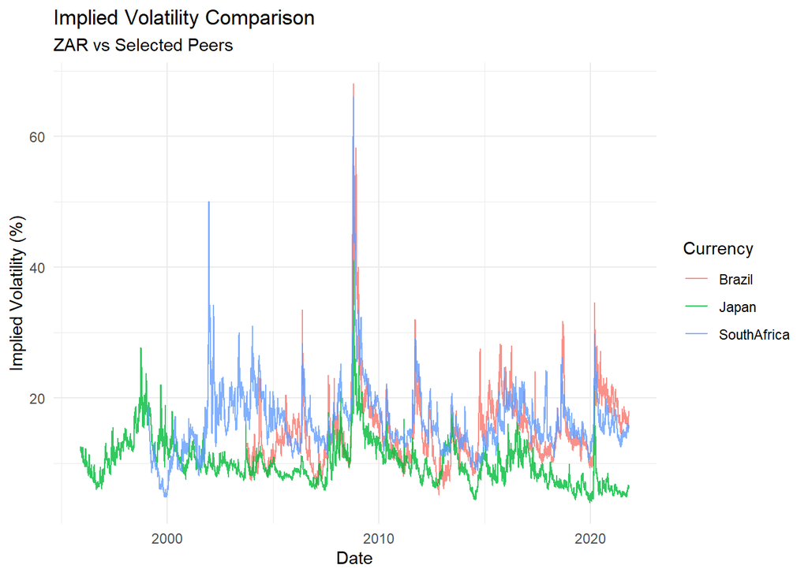

```r
# This captures market expectations about future volatility

# Step 1) Filter for selected IV series
iv_plot_data <- cncy_iv %>%
    filter(Name %in% c("SouthAfrica_IV", "Brazil_IV", "Japan_IV")) %>%
    mutate(Name = str_replace(Name, "_IV", ""))  # clean label

# Step 2) Plot
ggplot(iv_plot_data, aes(x = date, y = Price, color = Name)) +
    geom_line(alpha = 0.8) +
    labs(
        title = "Implied Volatility Comparison",
        subtitle = "ZAR vs Selected Peers",
        y = "Implied Volatility (%)",
        x = "Date",
        color = "Currency"
    ) +
    theme_minimal()
```

This confirms that implied volatility for ZAR often leads its peers, further affirming its status as a high-risk, high-beta currency in the eyes of the market.

Valuation Regime Analysis

Next, I test the hypothesis that ZAR performs better when undervalued (as might happen in risk-on carry trade environments).I did this using value deciles, I defined a “cheap” regime as the top 30% of ZAR value:

```r
# Investigating how the ZAR has performed during periods where it was "cheap"
# Confirm value data is loaded
glimpse(cncy_value)
```

```
## Rows: 8,240
## Columns: 3
## $ date  <date> 1990-01-01, 1990-01-02, 1990-01-03, 1990-01-04, 1990-01-05, 199…
## $ Name  <chr> "DBPPPUSF", "DBPPPUSF", "DBPPPUSF", "DBPPPUSF", "DBPPPUSF", "DBP…
## $ Price <dbl> 98.4211, 99.5730, 99.8575, 98.7614, 98.7911, 98.7413, 99.6439, 9…
```

```r
# Check available currency names
unique(cncy_value$Name)
```

```
## [1] "DBPPPUSF"
```

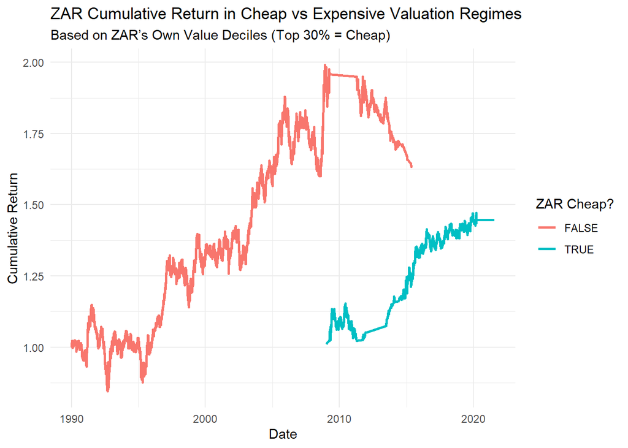

```r
# Step 1) Compute ZAR daily returns
zar_value <- cncy_value %>%
    arrange(date) %>%
    mutate(
        ret = Price / lag(Price) - 1
    )

# Step 2) Create value quantiles for ZAR
zar_value <- zar_value %>%
    mutate(
        value_quantile = ntile(Price, 10),  # Deciles
        is_cheap = value_quantile >= 8      # Top 30% = "cheap"
    )

# Step 3) Calculate cumulative returns by regime
zar_value_plot <- zar_value %>%
    filter(!is.na(ret)) %>%
    group_by(is_cheap) %>%
    arrange(date) %>%
    mutate(cum_return = cumprod(1 + ret)) %>%
    ungroup()

# Step 4: Plot
ggplot(zar_value_plot, aes(x = date, y = cum_return, color = factor(is_cheap))) +
    geom_line(size = 1) +
    labs(
        title = "ZAR Cumulative Return in Cheap vs Expensive Valuation Regimes",
        subtitle = "Based on ZAR’s Own Value Deciles (Top 30% = Cheap)",
        x = "Date", y = "Cumulative Return",
        color = "ZAR Cheap?"
    ) +
    theme_minimal()
```

The resulting chart shows that ZAR cumulative returns tend to be stronger in “cheap” valuation regimes, consistent with the idea that investors favour ZAR during risk-seeking environments.

All in all, my analysis supports both claims. ZAR is indeed among the most volatile currencies, based on both realised and implied volatility and it performs well in undervalued states. This is in line with global risk-on cycles and favourable G10 carry conditions.

Although I did not estimate GARCH models here due to limitations and errors that I ran into, the rolling volatilities, implied volatility data, and conditional performance plots serve as compelling proxies for volatility behaviour and market sentiment.

### Question 5 : Portfolio Construction

In this question, I was tasked with constructing a Global Balanced Index Fund portfolio using a mix of tradeable global indices provided in the datasets (MAA.rds and msci.rds)

The goal was to build a long-only portfolio that adheres to specific exposure contraints and is optimized based on risk (standard deviation) using monthly return data post 2010.

Loading data and packages

```r
# Load required packages and data
library(tidyverse)
library(lubridate)

# Set working directory to project root
setwd(here::here())

# Load series
MAA  <- read_rds("Data/MAA.rds")  %>% filter(Ticker %in% c("LUACTRUU Index", "LUAGTRUU Index", "BCOMTR Index", "LP05TREH Index"))
msci <- read_rds("Data/msci.rds") %>% filter(Name  %in% c("MSCI ACWI", "MSCI USA", "MSCI RE", "MSCI Jap", "MSCI China"))
```

Data preparation Using a custom function, I calculated monthly returns for each asset and filtered for those with at least 60 months of history.

```r
# Step 1) Prepare Monthly Returns
# Question wants monthly returns

# Create Helper Function (Monthly returns calculator)
library(PerformanceAnalytics)
get_monthly_returns <- function(df, price_col, name_col) {
    df %>%
        mutate(month = floor_date(date, "month")) %>%
        group_by(!!sym(name_col), month) %>%
        summarise(price = last(!!sym(price_col)), .groups = "drop") %>%
        group_by(!!sym(name_col)) %>%
        arrange(month) %>%
        mutate(ret = price / lag(price) - 1) %>%
        filter(!is.na(ret)) %>%
        rename(!!name_col := !!sym(name_col)) # keeps names clean and avoids duplicate 'date'
}

# Step 2) Apply function to both datasets
# Calculate monthly returns for both datasets (Make sure they are aligned)
MAA_ret <- get_monthly_returns(MAA, price_col = "Price", name_col = "Ticker")
msci_ret <- get_monthly_returns(msci, price_col = "Price", name_col = "Name")
```

Filtered for valid assets :

```r
# Step 3) Filter Valid Assets
# Question needs assets with at least 5 years (60 months) of data and data must be after 2010
# Create filter function
filter_assets <- function(ret_data, name_col = "Name") {
    ret_data %>%
        group_by(!!sym(name_col)) %>%
        filter(n() >= 60) %>%
        ungroup()
}

# Apply to both datasets
MAA_ret_filt <- filter_assets(MAA_ret, name_col = "Ticker")
msci_ret_filt <- filter_assets(msci_ret, name_col = "Name")

# Confirm the filtering process worked
glimpse(MAA_ret_filt)
```

```
## Rows: 948
## Columns: 4
## $ Ticker <chr> "BCOMTR Index", "LP05TREH Index", "LUACTRUU Index", "LUAGTRUU I…
## $ month  <date> 2002-02-01, 2002-02-01, 2002-02-01, 2002-02-01, 2002-03-01, 20…
## $ price  <dbl> 151.673, 111.890, 1220.230, 1174.170, 167.182, 111.110, 1197.56…
## $ ret    <dbl> 2.591280e-02, 0.000000e+00, 6.599408e-03, 9.231325e-03, 1.02252…
```

```r
glimpse(msci_ret_filt)
```

```
## Rows: 1,704
## Columns: 4
## $ Name  <chr> "MSCI Jap", "MSCI USA", "MSCI Jap", "MSCI USA", "MSCI Jap", "MSC…
## $ month <date> 1990-02-01, 1990-02-01, 1990-03-01, 1990-03-01, 1990-04-01, 199…
## $ price <dbl> 4802.359, 559.470, 3871.152, 572.231, 3920.013, 560.093, 4481.07…
## $ ret   <dbl> -0.103388293, 0.013991844, -0.193906162, 0.022809087, 0.01262182…
```

After filtering, I merged both datasets into a clean return matrix, and converted it to an xts object for optimization.

```r
# Step 4) Combine the 2 return datasets into a single dataset
# Dataset will be used to answer the question
library(janitor)
combined_ret <- bind_rows(
    MAA_ret_filt %>% rename(Name = Ticker),
    msci_ret_filt
) %>%
    clean_names()  # standardizing column names

glimpse(combined_ret)
```

```
## Rows: 2,652
## Columns: 4
## $ name  <chr> "BCOMTR Index", "LP05TREH Index", "LUACTRUU Index", "LUAGTRUU In…
## $ month <date> 2002-02-01, 2002-02-01, 2002-02-01, 2002-02-01, 2002-03-01, 200…
## $ price <dbl> 151.673, 111.890, 1220.230, 1174.170, 167.182, 111.110, 1197.560…
## $ ret   <dbl> 2.591280e-02, 0.000000e+00, 6.599408e-03, 9.231325e-03, 1.022529…
```

```r
# Step 6) Filter Data to Post 2010 period
combined_ret_post2010 <- combined_ret %>%
    filter(month >= as.Date("2010-01-01"))

# Confirm dimensions and available names
glimpse(combined_ret_post2010)
```

```
## Rows: 1,278
## Columns: 4
## $ name  <chr> "BCOMTR Index", "LP05TREH Index", "LUACTRUU Index", "LUAGTRUU In…
## $ month <date> 2010-01-01, 2010-01-01, 2010-01-01, 2010-01-01, 2010-02-01, 201…
## $ price <dbl> 258.9532, 158.2947, 1919.8200, 1756.9100, 268.5674, 158.8690, 19…
## $ ret   <dbl> -0.072779218, 0.018814917, 0.016315511, 0.014528656, 0.037127172…
```

```r
unique(combined_ret_post2010$name)
```

```
## [1] "BCOMTR Index"   "LP05TREH Index" "LUACTRUU Index" "LUAGTRUU Index"
## [5] "MSCI ACWI"      "MSCI China"     "MSCI Jap"       "MSCI RE"
## [9] "MSCI USA"
```

```r
library(tidyr)

# Step 7: Pivot data to wide format for portfolio analysis
wide_ret <- combined_ret_post2010 %>%
    select(month, name, ret) %>%
    pivot_wider(names_from = name, values_from = ret)

# Confirm structure
glimpse(wide_ret)
```

```
## Rows: 142
## Columns: 10
## $ month            <date> 2010-01-01, 2010-02-01, 2010-03-01, 2010-04-01, 2010…
## $ `BCOMTR Index`   <dbl> -0.072779218, 0.037127172, -0.012423697, 0.019442689,…
## $ `LP05TREH Index` <dbl> 0.0188149170, 0.0036280431, 0.0122704870, 0.005791625…
## $ `LUACTRUU Index` <dbl> 0.016315511, 0.003552416, 0.002989661, 0.018200166, -…
## $ `LUAGTRUU Index` <dbl> 0.0145286560, 0.0041151795, -0.0074880678, 0.00949780…
## $ `MSCI ACWI`      <dbl> -0.043209267, 0.012734813, 0.064328096, 0.001688948, …
## $ `MSCI China`     <dbl> -0.086291639, 0.022050423, 0.053826732, -0.005837903,…
## $ `MSCI Jap`       <dbl> 0.018982013, 0.011191380, 0.049941422, -0.001563515, …
## $ `MSCI RE`        <dbl> -0.060191107, 0.026338964, 0.059282371, 0.020544919, …
## $ `MSCI USA`       <dbl> -0.0353684829, 0.0301634914, 0.0594126374, 0.01571746…
```

Portfolio Optimization

I constructed a portfolio using PortfolioAnalytics, adding constraints and optimizing based on standard deviation.

```r
# Portfolio optimization

# STEP 1) Load required packages
library(PortfolioAnalytics)
library(tidyverse)
library(PerformanceAnalytics)
library(ROI)
library(ROI.plugin.quadprog)
library(xts)
library(janitor)

# STEP 2) Ensure column names are clean
wide_ret <- wide_ret %>% clean_names()

# STEP 3) Convert returns to xts object
returns_xts <- xts(wide_ret[,-1], order.by = wide_ret$month)
colnames(returns_xts) <- make.names(colnames(returns_xts))


# STEP 4) Initialize portfolio with assets
assets <- colnames(returns_xts)
# Define groups
group_list <- list(
    Commodities = which(grepl("BCOMTR", assets)),
    Bonds = which(grepl("LPO5TREH|LUACTRUU|LUAGTRUU", assets)),
    Equities = which(grepl("MSCI", assets))
)

# STEP 5) Add constraints
port_spec <- portfolio.spec(assets = assets) %>%
    add.constraint(type = "full_investment") %>%
    add.constraint(type = "long_only") %>%
    add.constraint(type = "group",
                   groups = group_list,
                   group_min = c(0, 0, 0),  # allow 0% allocations
                   group_max = c(0.15, 0.25, 0.60)) %>%
    add.constraint(type = "box", min = 0, max = 0.35) %>%
    add.objective(type = "risk", name = "StdDev")

# Step 6) Run optimization
opt_result <- optimize.portfolio(
    R = returns_xts,
    portfolio = port_spec,
    optimize_method = "ROI",
    trace = TRUE
)
```

```r
# Step 7) Extract the weights
weights <- extractWeights(opt_result)
print(weights)
```

```
##   bcomtr_index lp05treh_index luactruu_index luagtruu_index      msci_acwi
##   6.089302e-02   3.500000e-01   1.869051e-01   3.500000e-01   7.210804e-17
##     msci_china       msci_jap        msci_re       msci_usa
##  -3.469447e-18   5.220188e-02  -8.551211e-19   6.255887e-18
```

```r
# Present weights in a nice table
# Load packages
library(knitr)
library(dplyr)

# Create tidy table of weights
weights_tbl <- tibble(
    Asset = names(weights),
    Weight = as.numeric(weights)
) %>%
    arrange(desc(Weight))  # Largest to smallest

# Display the weights in a nice table
kable(weights_tbl, digits = 4, caption = "Optimized Portfolio Weights (Post-2010)")
```

Optimized Portfolio Weights (Post-2010)

| Asset | Weight |
| --- | --- |
| luagtruu_index | 0.3500 |
| lp05treh_index | 0.3500 |
| luactruu_index | 0.1869 |
| bcomtr_index | 0.0609 |
| msci_jap | 0.0522 |
| msci_acwi | 0.0000 |
| msci_usa | 0.0000 |
| msci_re | 0.0000 |
| msci_china | 0.0000 |

Portfolio Performance

To assess performance, I computed and plotted the cumulative returns of the optimized portfolio.

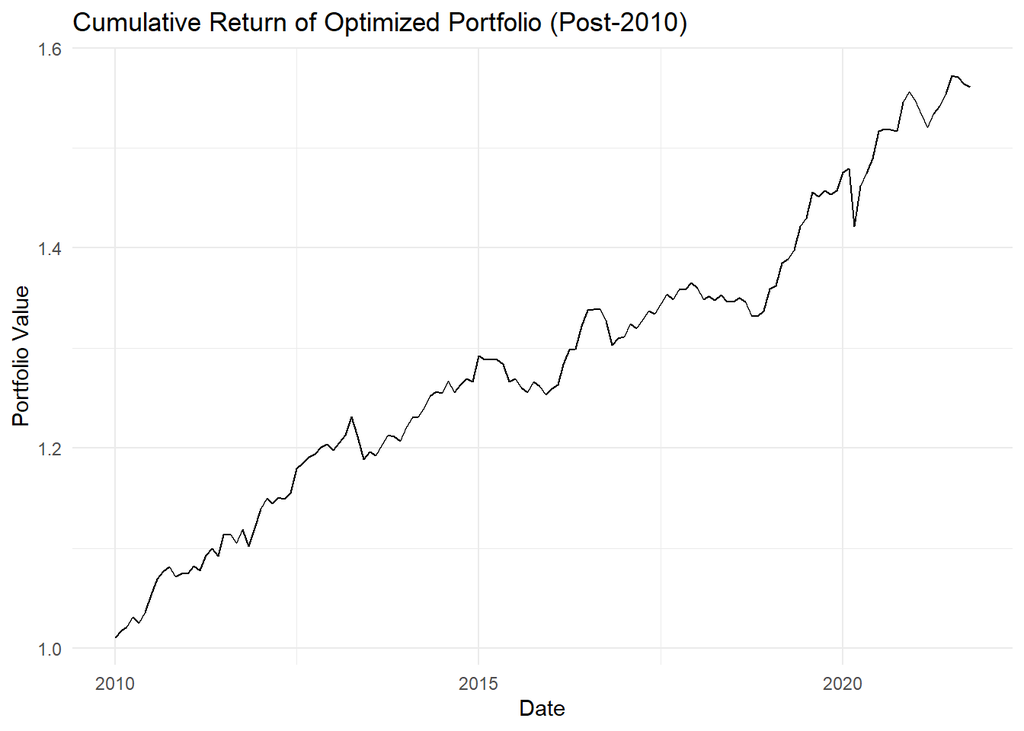

```r
# Create a portfolio performance chart
# Load required libraries
library(ggplot2)

# Step 1) Calculate weighted returns
weighted_returns <- returns_xts %*% weights

# Step 2) Convert to xts object and name the column
portfolio_returns_xts <- xts(weighted_returns, order.by = index(returns_xts))
colnames(portfolio_returns_xts) <- "Portfolio"

# Step 3) Calculate cumulative return
cumulative_returns <- cumprod(1 + portfolio_returns_xts)

# Step 4) Plot the cumulative return
autoplot(cumulative_returns, facets = NULL) +
    labs(
        title = "Cumulative Return of Optimized Portfolio (Post-2010)",
        y = "Portfolio Value",
        x = "Date"
    ) +
    theme_minimal()
```